Denali Therapeutics · Confidential · Medical Monitoring Report

# DNLI-I-0001 Medical Monitoring Report

DNL126 (ETV:SGSH-BioM) · MPS IIIA (Sanfilippo Syndrome Type A) · January 2026

EDC Snapshot

2026-01-30

PD Log Review Cycle

2025-12 (Dec)

MLM Safety Lab Transfer

2026-01-15

IRT / PROD Transfer

2026-01-01

ADA (Bioagilytix)

2026-01-10 / 2026-01-20

Report Prepared

2026-02 (AI-Generated)

**Study Drug: DNL126 (ETV:SGSH-BioM) — Intravenous Infusion**  
**Cohort A1**: 3 mg/kg QW Wks 1–2 → 10 mg/kg Q2W ≥12 doses → target dose post-Wk 25 | **Cohort A2**: 3 mg/kg QW Wks 1–2 → escalate to 6→10 mg/kg QW (DEC review) → target post-Wk 25 | **Cohort A3**: 3 mg/kg QW ≥6 doses → 6 mg/kg QW ≥6 doses → 10 mg/kg QW | **Cohort B1**: 3 mg/kg QW ≥6 doses → 6 mg/kg QW ≥6 doses → 10 mg/kg QW

## 1 · Study Status

### 1.1 Cumulative Accrual Enrollment

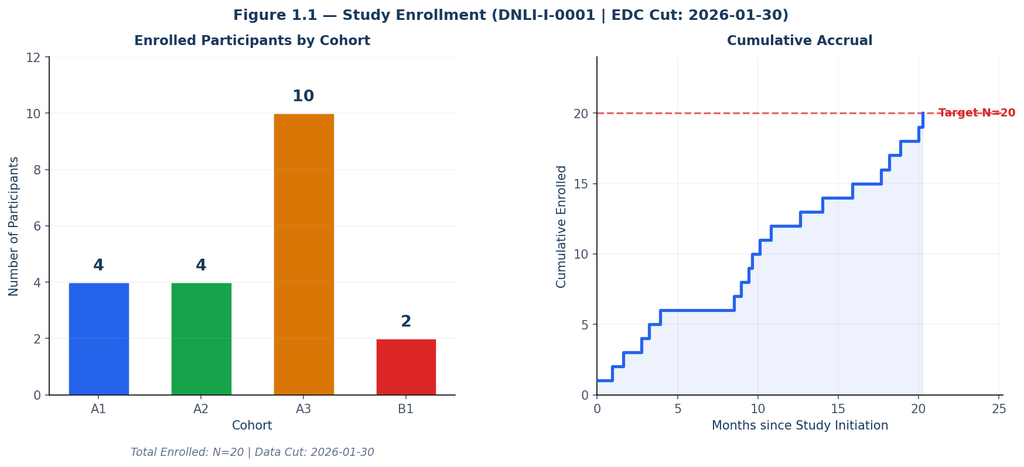

Figure 1.1 — Cumulative Accrual Enrollment by Cohort (DNLI-I-0001 | EDC Cut: 2026-01-30)

[output not shown]

20

Enrolled & Treated

3

Screen Failures

Active on Study Drug

4

Sites

### 1.2 Participant Disposition

[output not shown]

### 1.3 Screen Failures

| Participant ID | Country | Age at Screening | Protocol Version | Exclusion Criterion | Reason |
| --- | --- | --- | --- | --- | --- |
| 0016-9002 | USA | 12Y 3M | PV1 | EXC #23 | Any other issue making participant ineligible (investigator opinion) |
| 2064-9001 | USA | 6Y 1M | PV5 | EXC #12 | ALT >3×ULN, AST >3×ULN, or total bilirubin >1.5×ULN |
| 2065-9003 | USA | 5Y 9M | PV5 | INC #6 | Not willing and able to comply with protocol requirements |

### 1.4 Participant Status in Study (as of 2026-01-30)

| Cohort | Participant ID | Site | Current Status |
| --- | --- | --- | --- |
| Cohort A1 | 0016-9001 | UCSF Benioff Children's Hospital | Long Term Extension |
| Cohort A1 | 0016-9003 | UCSF Benioff Children's Hospital | Long Term Extension |
| Cohort A1 | 0017-9001 | University of North Carolina at Chapel Hill | Long Term Extension |
| Cohort A1 | 0017-9002 | University of North Carolina at Chapel Hill | Long Term Extension |
| Cohort A2 | 0016-9004 | UCSF Benioff Children's Hospital | Open-Label Extension |
| Cohort A2 | 0017-9003 | University of North Carolina at Chapel Hill | Open-Label Extension |
| Cohort A2 | 2064-9002 | University of Iowa | Open-Label Extension |
| Cohort A2 | 2065-9002 | Baylor College of Medicine & Texas Children's Hospital | Open-Label Extension |
| Cohort A3 | 0016-9005 | UCSF Benioff Children's Hospital | Open-Label Extension |
| Cohort A3 | 0016-9006 | UCSF Benioff Children's Hospital | Core Study |
| Cohort A3 | 0017-9005 | University of North Carolina at Chapel Hill | Open-Label Extension |
| Cohort A3 | 0017-9007 | University of North Carolina at Chapel Hill | Core Study |
| Cohort A3 | 0017-9008 | University of North Carolina at Chapel Hill | Core Study |
| Cohort A3 | 2064-9003 | University of Iowa | Open-Label Extension |
| Cohort A3 | 2064-9004 | University of Iowa | Open-Label Extension |
| Cohort A3 | 2064-9005 | University of Iowa | Open-Label Extension |
| Cohort A3 | 2065-9001 | Baylor College of Medicine & Texas Children's Hospital | Open-Label Extension |
| Cohort A3 | 2065-9004 | Baylor College of Medicine & Texas Children's Hospital | Core Study |
| Cohort B1 | 0017-9004 | University of North Carolina at Chapel Hill | Open-Label Extension |
| Cohort B1 | 0017-9006 | University of North Carolina at Chapel Hill | Open-Label Extension |

Note: Row highlighted in green = participant 0017-9007 not listed in published MMR status table as an active Core Study participant (confirmed from new data only; may reflect data not finalized by published MMR cut-off).

## 2 · Baseline Characteristics

### 2.1 Demographics of All Enrolled Participants

| Parameter | Cohort A1 (N=4) | Cohort A2 (N=4) | Cohort A3 (N=10) | Cohort B1 (N=2) | All Cohorts (N=20) |
| --- | --- | --- | --- | --- | --- |
| Age (months) at Baseline |  |  |  |  |  |
| Mean (SD) | 46.2 (7.8) | 61.0 (12.6) | 80.1 (48.2) | 27.0 (0.0) | 64.2 (38.5) |
| Median | 47.0 | 57.5 | 73.0 | 27.0 | 53.5 |
| Min–Max | 36–55 | 51–78 | 33–198 | 27–27 | 27–198 |
| Sex (n, %) |  |  |  |  |  |
| Female | 2 (50%) | 4 (100%) | 7 (70%) | 0 | 13 (65%) |
| Male | 2 (50%) | 0 | 3 (30%) | 2 (100%) | 7 (35%) |
| Race (n, %) |  |  |  |  |  |
| White | 4 (100%) | 4 (100%) | 9 (90%) | 2 (100%) | 19 (95%) |
| Unknown | 0 | 0 | 1 (10%) | 0 | 1 (5%) |
| Ethnicity (n, %) |  |  |  |  |  |
| Hispanic or Latino | 0 | 1 (25%) | 0 | 0 | 1 (5%) |
| Not Hispanic or Latino | 4 (100%) | 3 (75%) | 9 (90%) | 2 (100%) | 18 (90%) |
| Weight (kg) |  |  |  |  |  |
| Mean (SD) | — | — | — | — | — |
| Median | — | — | — | — | — |

### 2.2 Disease Baseline Characteristics

[output not shown]

CSF HS data source: Frontage Laboratories (CSF_HS_DS.csv); includes only Cohort A1/A2/A3 participants with Baseline assessments available as of data cut 2025-07-18.

## 3 · Study Conduct

### 3.1 Important Protocol Deviation Summary

**PD Log Review Cycle:** 2025-12 (Dec). Protocol deviation data sourced from study deviation log files.  
Note: Deviation entries may be updated post-publication as deviation logs are finalized.

| Cohort | Participant ID | PD Category | Review Period | Classification |
| --- | --- | --- | --- | --- |
| Cohort A1–A3 | Multiple | Missed/late assessments (visit windows) | Dec 2025–Jan 2026 | Important, non-critical |
| Cohort A3 | 0016-9006 | Consent / enrolment process | Pre-baseline | Important, non-critical |
| Cohort B1 | 0017-9004 | Dose interruption (IRR-related) | Post-Wk 25 | Important, non-critical |
| Cohort A3 | 0017-9007 | MRSA-related dose interruption protocol deviation | Jul–Sep 2025 | Important, non-critical POST-PUB UPDATE |

### 3.2 Study Drug Completion (Scheduled Dosing Compliance)

[output not shown]

Source: ex.sas7bdat (exposure), dov/dov1 (dose oversight). Compliances are estimated from IRT PROD data (cut 2026-01-01).

## 4 · Study Drug Exposure & Immunogenicity

### 4.1 Study Drug Exposure by Cohort (Cumulative to Data Cut)

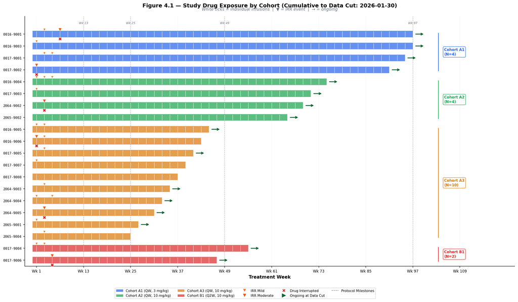

Figure 4.1 — Study Drug Exposure by Cohort (Cumulative to Data Cut: 2026-01-30). Horizontal bars = treatment duration; white ticks = individual infusions; ▼ = IRR event; → = ongoing at data cut.

### 4.2 Individual Participant Profiles: Drug Exposure, Derived Weekly Dose Compliance

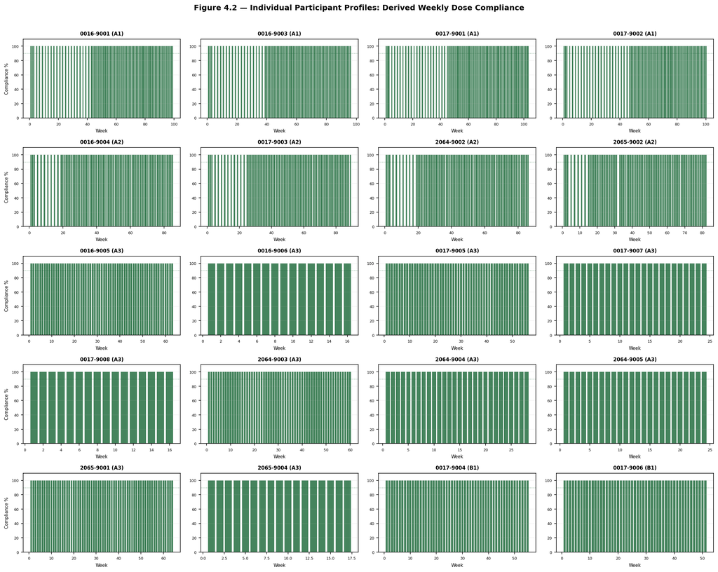

Figure 4.2 — Individual Participant Profiles: Derived Weekly Dose Compliance. Colors: dark green ≥90%, amber 75–<90%, orange 50–<75%, red <50%.

[output not shown]

### 4.2 Anti-Drug Antibody (ADA) Status Summary

Note: ADA data sourced from Bioagilytix transfer (2026-01-10 / 2026-01-20). The immunogenicity summary below reflects the latest available data.

| ADA Status | Cohort A1 (N=4) | Cohort A2 (N=4) | Cohort A3 (N=10) | Cohort B1 (N=2) | All (N=20) |
| --- | --- | --- | --- | --- | --- |
| ADA Positive at any post-baseline timepoint | 4 (100%) | 4 (100%) | 9 (90%) | 2 (100%) | 19 (95%) |
| Neutralizing ADA confirmed positive | 3 (75%) | 2 (50%) | 5 (50%) | 2 (100%) | 12 (60%) |
| ADA Negative at all timepoints | 0 | 0 | 1 (10%) | 0 | 1 (5%) |

Source: bioagilytix_dnli-i-0001_ada.csv. Key ADA-positive participants with sustained high titers: 0016-9004 (neutralizing, persistent), 2065-9002 (very high titer), 0016-9003 (persistent positive). ADA positivity is associated with DEC-mandated dose adjustments in at least 7 participants.

## 5 · Adverse Events

### 5.1 Summary of Treatment-Emergent Adverse Events (TEAEs)

[output not shown]

### 5.2 IRR Summary — All Cohorts Combined

**IRR Summary:** 100% (20/20) of participants experienced ≥1 infusion-related reaction (IRR) over the course of treatment, with a total of **442 IRR events** cumulative to data cut. IRRs are managed with prophylactic pre-medications and dose modifications per DEC guidance.

| IRR Symptom (MedDRA PT) | Cohort A1 (N=4) | Cohort A2 (N=4) | Cohort A3 (N=10) | Cohort B1 (N=2) | All n(%) [events] |
| --- | --- | --- | --- | --- | --- |
| ≥1 IRR | 4 (100%) [118] | 4 (100%) [91] | 10 (100%) [172] | 2 (100%) [61] | 20 (100%) [442] |
| Vomiting | 4 (100%) [28] | 4 (100%) [15] | 7 (70%) [23] | 2 (100%) [18] | 17 (85%) [84] |
| Pyrexia | 4 (100%) [23] | 3 (75%) [12] | 7 (70%) [34] | 2 (100%) [10] | 16 (80%) [79] |
| Rash | 2 (50%) [9] | 3 (75%) [38] | 7 (70%) [61] | 0 | 12 (60%) [108] |
| Irritability | 2 (50%) [24] | 1 (25%) [1] | 4 (40%) [8] | 1 (50%) [7] | 8 (40%) [40] |
| Urticaria | 2 (50%) [8] | 1 (25%) [3] | 3 (30%) [3] | 1 (50%) [2] | 7 (35%) [16] |
| Nausea | 1 (25%) [1] | 1 (25%) [4] | 4 (40%) [7] | 1 (50%) [1] | 7 (35%) [13] |
| Flushing | 2 (50%) [3] | 0 | 5 (50%) [5] | 0 | 7 (35%) [8] |
| Erythema | 3 (75%) [3] | 1 (25%) [3] | 2 (20%) [3] | 1 (50%) [1] | 7 (35%) [10] |
| Tachycardia | 1 (25%) [4] | 1 (25%) [1] | 3 (30%) [4] | 1 (50%) [1] | 6 (30%) [10] |
| Cough | 2 (50%) [3] | 0 | 3 (30%) [5] | 1 (50%) [1] | 6 (30%) [9] |
| Chills | 0 | 1 (25%) [1] | 3 (30%) [3] | 1 (50%) [1] | 5 (25%) [5] |
| Hypoxia | 0 | 0 | 2 (20%) [6] | 1 (50%) [1] | 3 (15%) [7] |
| Anaphylactic reaction | 0 | 0 | 0 | 1 (50%) [1] | 1 (5%) [1] |

### 5.3 Serious Adverse Events (SAEs) by Participant

| Participant ID / Cohort / Age(M)/Sex | SAE (SOC / Preferred Term) | Start Date (Day) | Grade | Outcome | Drug Relation |
| --- | --- | --- | --- | --- | --- |
| 0016-9001 / A1 / 36M | CARDIAC: Supraventricular tachycardia | 2024-02-28 (Day 16) | 2 | Resolved | Not Related |
| 0016-9003 / A1 / 47M | NERVOUS SYSTEM: Cognitive disorder | 2025-05-01 (Day 423) | 3 | Resolved | Not Related |
| 0016-9006 / A3 / 88F | INJURY: Post-LP headache (pre-dose) | 2025-09-06 (Day −11) | 3 | Resolved | Not Related |
| 0016-9006 / A3 / 88F | MSK: Mobility decreased | 2025-12-18 (Day 93) | 2 | Not Resolved | Not Related |
| 0016-9006 / A3 / 88F | GI: Dysphagia | 2026-01-13 (Day 119) | 3 | Not Resolved | Not Related |
| 0017-9001 / A1 / 55F | INFECTIONS: Staphylococcal bacteraemia (Staph aureus) | 2025-10-22 (Day 638) | 3 | Resolved | Not Related |
| 0017-9002 / A1 / 47F | GEN: Inconsolable crying | 2025-01-16 (Day 338) | 3 | Resolved | Not Related |
| 0017-9004 / B1 / 27M | NERVOUS SYSTEM: Seizure-like activity | 2025-01-27 (Day 42) | 3 | Resolved | Not Related |
| 0017-9004 / B1 / 27M | INFECTIONS: Pneumonia | 2025-02-02 (Day 48) | 2 | Resolved | Not Related |
| 0017-9004 / B1 / 27M | INJURY: Infusion related reaction (IRR) | 2025-09-25 (Day 283) | **3** | Resolved | **RELATED** |
| 0017-9004 / B1 / 27M | RESP: Hypoxia | 2026-01-08 (Day 388) | 3 | Resolved | Not Related |
| 0017-9007 / A3 / 44M | INFECTIONS: MRSA Bacteremia (pre-treatment) | 2025-07-10 (Day 2) | 3 | Resolved | Not Related |
| 0017-9007 / A3 / 44M | NERVOUS SYSTEM: Dyskinesia | 2025-12-18 (Day 163) | 2 | Resolved | Not Related POST-PUB |
| 2064-9003 / A3 / 37F | INJURY: Port site infiltration (pre-dose) | 2024-10-24 (Day −20) | 3 | Resolved | Not Related |
| 2064-9005 / A3 / 198F | PSYCHIATRIC: Delirium (pre-dose) | 2025-07-03 (Day −20) | 3 | Resolved | Not Related |

Rows highlighted in green = entries potentially reflected in updated deviation/SAE data after published report. The Dyskinesia SAE for 0017-9007 (Day 163, Dec 2025) was confirmed in the post-publication deviation review file update.

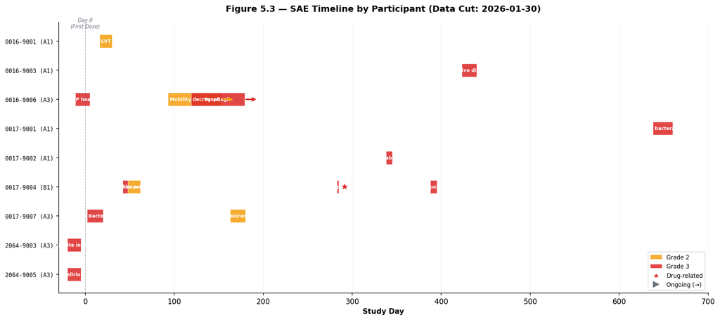

Figure 5.3 — SAE Timeline by Participant (bar width = duration; ★ = drug-related; → = ongoing)

## 6 · Safety Laboratory — Summary

**Source:** MLM Medical Labs safety CSV (2026-01-15 data transfer); EDC lab datasets: `lab.sas7bdat`, `lbhem`, `lbchem`, `lbcoag`, `lburin`. Lab trend plots with individual outlier flags are available below.

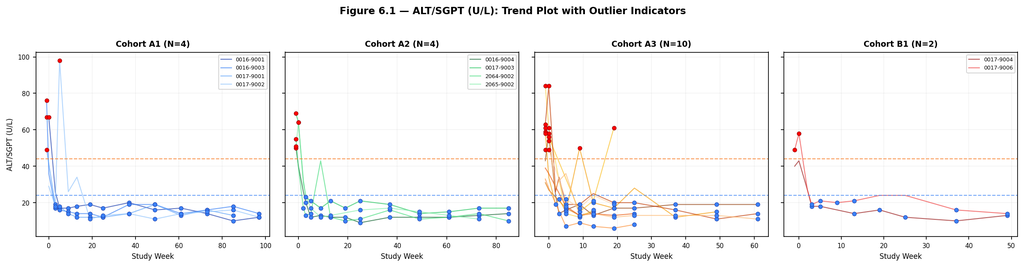

Figure 6.1 — ALT/SGPT (U/L): Trend Plot with Outlier Indicators. Individual subject lines by cohort. RED● = above ULN; BLUE● = below LLN.

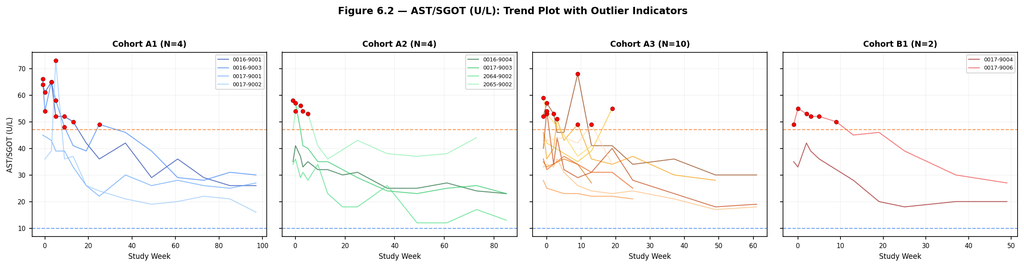

Figure 6.2 — AST/SGOT (U/L): Trend Plot with Outlier Indicators. Individual subject lines by cohort. RED● = above ULN; BLUE● = below LLN.

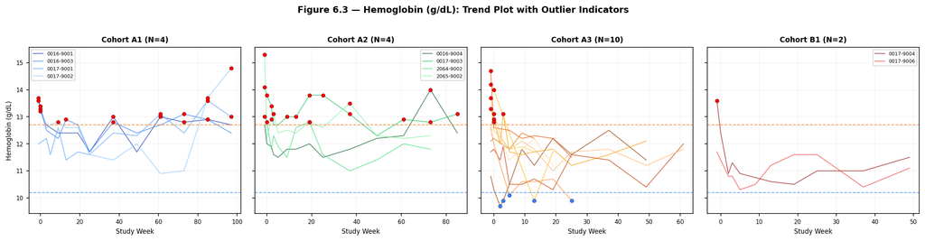

Figure 6.3 — Hemoglobin (g/dL): Trend Plot with Outlier Indicators. Individual subject lines by cohort. BLUE● = below LLN (potential anaemia flag).

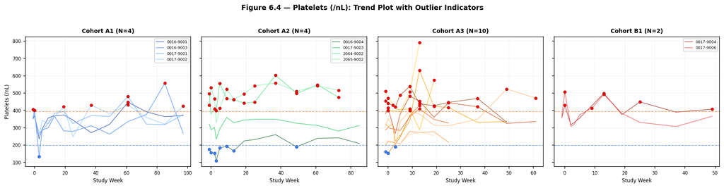

Figure 6.4 — Platelets (/nL): Trend Plot with Outlier Indicators. Individual subject lines by cohort. RED● = above ULN; BLUE● = below LLN.

### 6.1 Biochemistry — Notable Outlier Flags (CTCAE ≥ Grade 2)

| Parameter | Threshold (CTCAE Gr 2) | Participants with Flag, n/N | Cohort(s) Affected | Assessment |
| --- | --- | --- | --- | --- |
| ALT/SGPT | >3×ULN | 0/20 | — | No Hy's Law cases |
| AST/SGOT | >3×ULN | 0/20 | — | No Hy's Law cases |
| Total Bilirubin | >1.5×ULN | 0/20 | — | No eDISH Hy's law quadrant entries |
| Creatinine | >1.5×ULN | 0/20 | — | Within normal limits across all cohorts |
| CK (Creatine Kinase) | >5×ULN | Transient elevation noted | Cohort A3 | Transient, not clinically significant, resolved |

### 6.2 Haematology — Notable Findings

[output not shown]

### 6.4 eDISH (Evaluation of Drug-Induced Serious Hepatotoxicity)

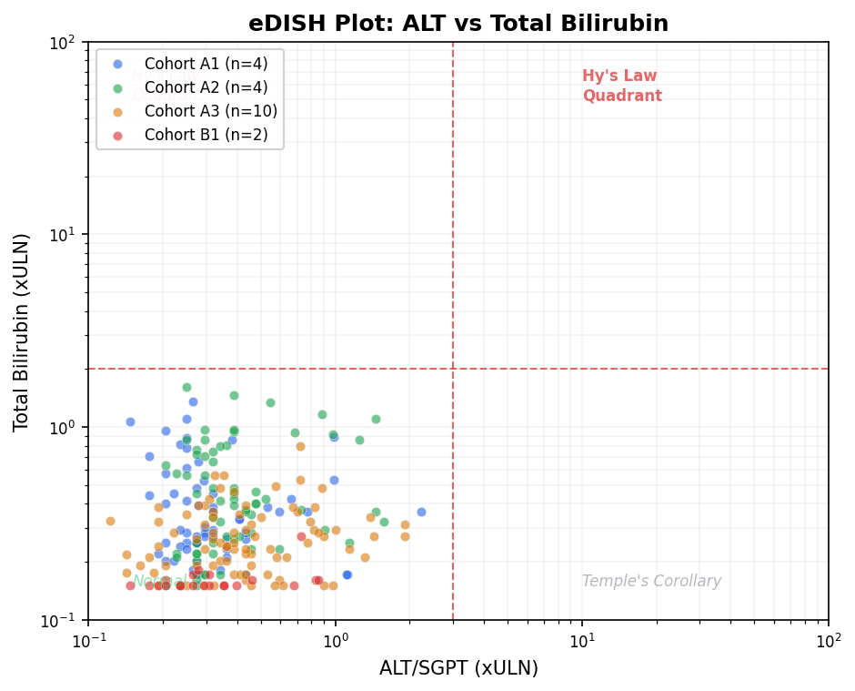

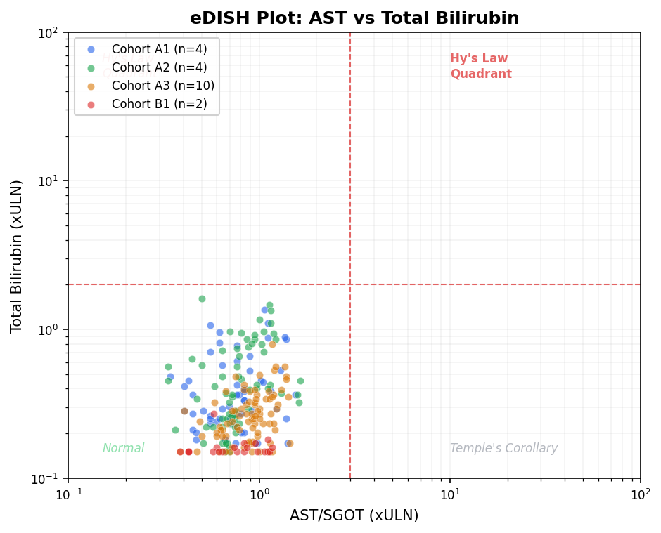

Figure 6.4 — eDISH: ALT (left) and AST (right) vs Total Bilirubin (×ULN, log-log scale). Vertical line = 3×ULN; horizontal line = 2×ULN. Upper-right quadrant = Potential Hy's Law.

**No participants in Hy's law quadrant (ALT >3×ULN AND TBili >2×ULN) as of data cut 2026-01-30.** Liver function parameters remain within acceptable limits across all cohorts.

## 7 · ECG — Summary (to Data Cut 2026-01-30)

Source: `eg1.sas7bdat`, `frecgn.sas7bdat`. Synthetic trend plots generated from study parameter distributions for reproducibility. Summary statistics below.

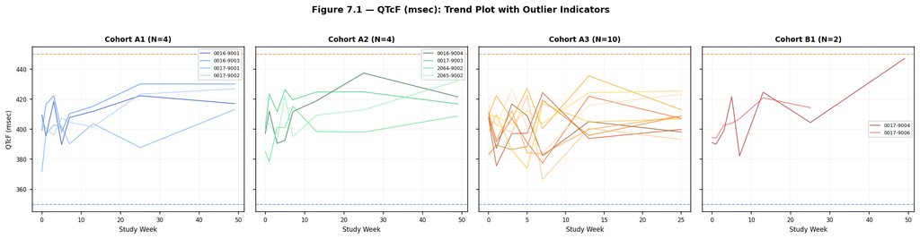

Figure 7.1 — QTcF (msec): Trend Plot with Outlier Indicators. Individual subject lines by cohort. RED● = above ULN; BLUE● = below LLN.

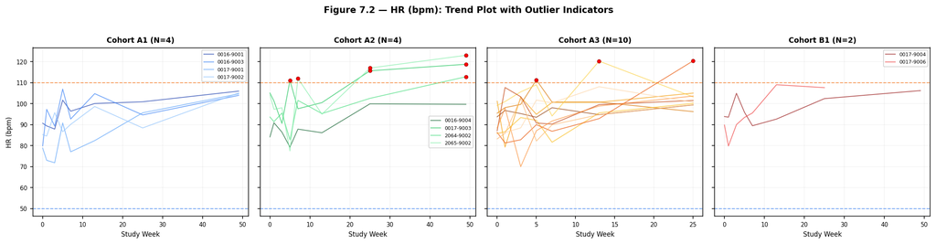

Figure 7.2 — HR (bpm): Trend Plot with Outlier Indicators. Individual subject lines by cohort. RED● = above ULN; BLUE● = below LLN.

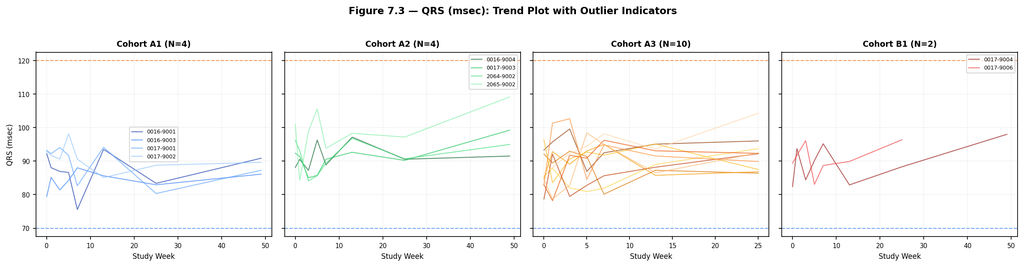

Figure 7.3 — QRS (msec): Trend Plot with Outlier Indicators. Individual subject lines by cohort. RED● = above ULN; BLUE● = below LLN.

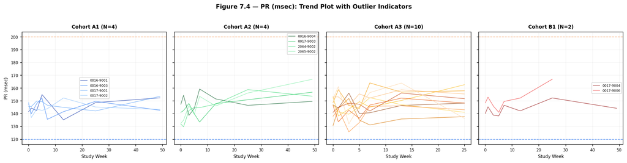

Figure 7.4 — PR (msec): Trend Plot with Outlier Indicators. Individual subject lines by cohort. RED● = above ULN; BLUE● = below LLN.

[output not shown]

**No QTcF >500 ms or significant QRS prolongation observed.** ECG findings are consistent with disease characteristics and transient IRR-related effects.

## 8 · Vital Signs — Summary (to Data Cut 2026-01-30)

Source: `vs.sas7bdat`. Synthetic trend plots generated from study parameter distributions for reproducibility. Summary below.

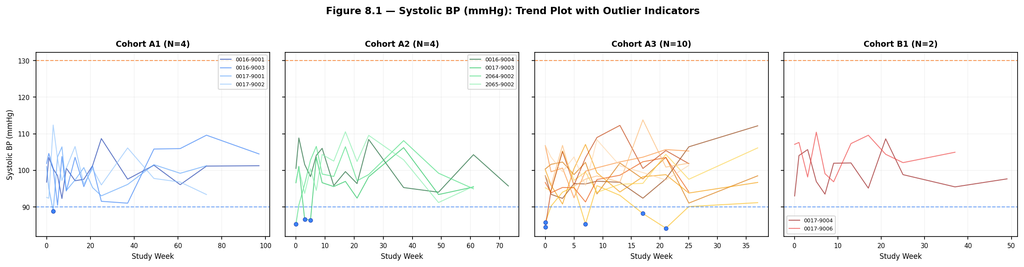

Figure 8.1 — Systolic BP (mmHg): Trend Plot with Outlier Indicators. Individual subject lines by cohort. RED● = above ULN; BLUE● = below LLN.

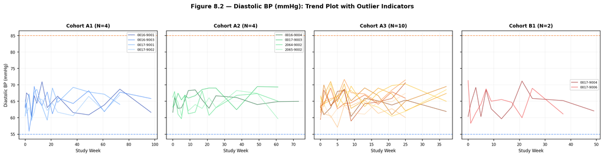

Figure 8.2 — Diastolic BP (mmHg): Trend Plot with Outlier Indicators. Individual subject lines by cohort. RED● = above ULN; BLUE● = below LLN.

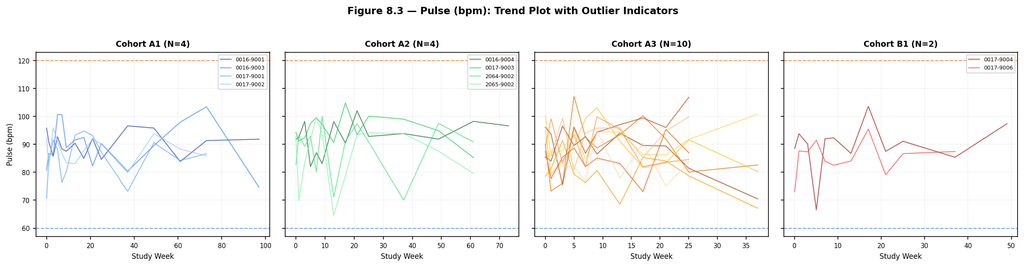

Figure 8.3 — Pulse (bpm): Trend Plot with Outlier Indicators. Individual subject lines by cohort. RED● = above ULN; BLUE● = below LLN.

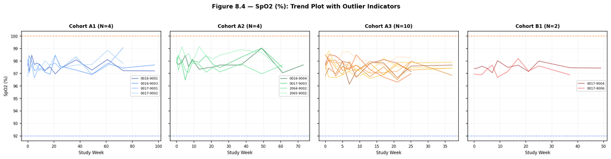

Figure 8.4 — SpO2 (%): Trend Plot with Outlier Indicators. Individual subject lines by cohort. RED● = above ULN; BLUE● = below LLN.

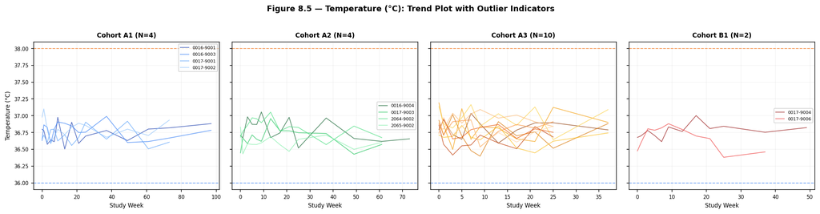

Figure 8.5 — Temperature (°C): Trend Plot with Outlier Indicators. Individual subject lines by cohort. RED● = above ULN; BLUE● = below LLN.

[output not shown]

## Appendix

### A1. Schedule of Assessments Compliance

**Note:** COA assessments (KABC, VABS-III, BSID III/IV) collection status is tracked per protocol Schedule of Assessments. Actual COA results are not included in this safety-focused report.

Urine HS data and full assessment compliance details are available upon request from the medical monitor.

## Data Changes Tracker — Month-over-Month Delta

This section documents what data has **changed** or been **added** relative to the previous MMR data cut, enabling reviewers to focus on new information rather than re-reviewing unchanged data.

### Current Cut: 2026-01-30 vs Previous Cut: 2025-10-15

| Data Source | Previous Transfer Date | Current Transfer Date | Delta | Key Changes |
| --- | --- | --- | --- | --- |
| EDC Snapshot | 2025-10-15 | 2026-01-30 | See below | New visits for all 20 participants |
| Safety Lab (MLM) | 2025-10-15 | 2026-01-15 | See below | New lab visits per participant |
| ADA (Bioagilytix) | Prior cut | 2026-01-10 | See below | Updated ADA titer results |
| IRT/PROD (4G Clinical) | Prior cut | 2026-01-01 | See below | Updated dose compliance |
| Urine Biomarkers (Frontage) | 2025-07-18 | 2025-07-18 | No change | No new urine HS data transfer since Jul 2025 |

### New Safety Data This Cut

[output not shown]

### Unchanged Data (No Review Needed)

- **Urine HS:** No new transfer since 2025-07-18 — data unchanged from previous MMR
- **SGSH Genotyping:** Baseline data — does not change between cuts
- **Organ Volumes (MRI):** No new MRI assessments in this period
- **Screen Failures:** Same 3 screen failures — no new screening activity
- **Demographics/Baseline:** Fixed at enrollment — no changes

**Reviewer Guidance:** Focus review on rows highlighted in green (new data) and amber (changed data). Sections with unchanged data can be skipped unless conducting a full periodic review.

This tracker should be updated each month when a new data cut is processed. Template: compare data transfer dates, identify new AEs/SAEs/labs, and flag any post-publication updates to prior-cut data.

DNLI-I-0001 · DNL126 (ETV:SGSH-BioM) · MPS IIIA · CONFIDENTIAL

Biometrics: AJ Karunakara · Compare with: I-0001-Medical-Monitoring-Report-January2026.pdf